# Gam model: stillbirth

# Birthweight

## 2007-2020

```r
m_BW_bam5_2 <- bam(BW ~ s(GA_weeks) +  s(mat_age, k=7) + s(birth_Y_M_num) + s(month) + s(mean_ssep2) + parity_cat + sex + Urban3 + Language + mother_nationality_cat2, data=bevn_eco_in7)
  summary(m_BW_bam5_2)
```

```
##
## Family: gaussian
## Link function: identity
##
## Formula:
## BW ~ s(GA_weeks) + s(mat_age, k = 7) + s(birth_Y_M_num) + s(month) +
##     s(mean_ssep2) + parity_cat + sex + Urban3 + Language + mother_nationality_cat2
##
## Parametric coefficients:
##                                                       Estimate Std. Error  t value Pr(>|t|)
## (Intercept)                                          3335.2704     0.8361 3989.044  < 2e-16 ***
## parity_cat(1,2]                                       127.4692     0.8344  152.762  < 2e-16 ***
## parity_cat(2,3]                                       173.6260     1.2772  135.939  < 2e-16 ***
## parity_cat(3,20]                                      199.6977     2.2149   90.160  < 2e-16 ***
## sex2                                                 -147.0101     0.7458 -197.128  < 2e-16 ***
## Urban3                                                  0.6608     0.7906    0.836    0.403
## LanguageFrench                                        -48.0924     0.9182  -52.374  < 2e-16 ***
## LanguageItalian                                       -63.1878     2.0493  -30.834  < 2e-16 ***
## mother_nationality_cat2Africa                          11.0168     2.2735    4.846 1.26e-06 ***
## mother_nationality_cat2Asia                           -17.9253     2.0596   -8.703  < 2e-16 ***
## mother_nationality_cat2Europe                          32.5679     0.8501   38.310  < 2e-16 ***
## mother_nationality_cat2Northern America                65.0093     4.8546   13.391  < 2e-16 ***
## mother_nationality_cat2Oceania                         63.4678    11.1288    5.703 1.18e-08 ***
## mother_nationality_cat2Southern and Central America    47.0493     2.7991   16.809  < 2e-16 ***
## ---
## Signif. codes:  0 '***' 0.001 '**' 0.01 '*' 0.05 '.' 0.1 ' ' 1
##
## Approximate significance of smooth terms:
##                    edf Ref.df         F p-value
## s(GA_weeks)      8.826  8.988 73217.048  <2e-16 ***
## s(mat_age)       5.178  5.693    20.286  <2e-16 ***
## s(birth_Y_M_num) 8.285  8.859    39.009  <2e-16 ***
## s(month)         5.893  7.053     3.183  0.0022 **
## s(mean_ssep2)    7.634  8.534    43.693  <2e-16 ***
## ---
## Signif. codes:  0 '***' 0.001 '**' 0.01 '*' 0.05 '.' 0.1 ' ' 1
##
## R-sq.(adj) =  0.401   Deviance explained = 40.1%
## fREML = 8.1205e+06  Scale est. = 1.5259e+05  n = 1099328
```

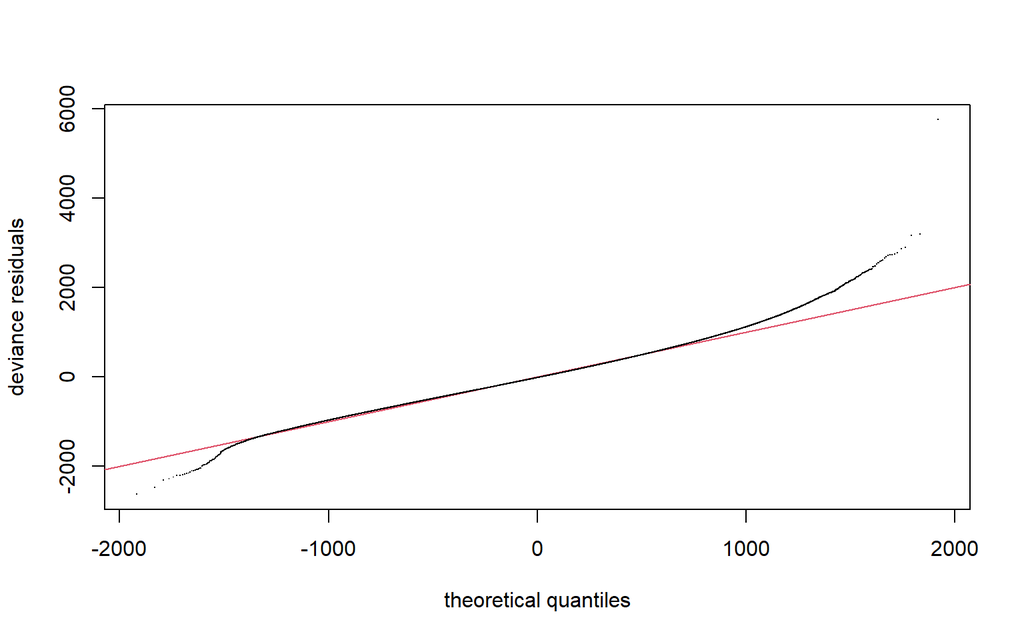

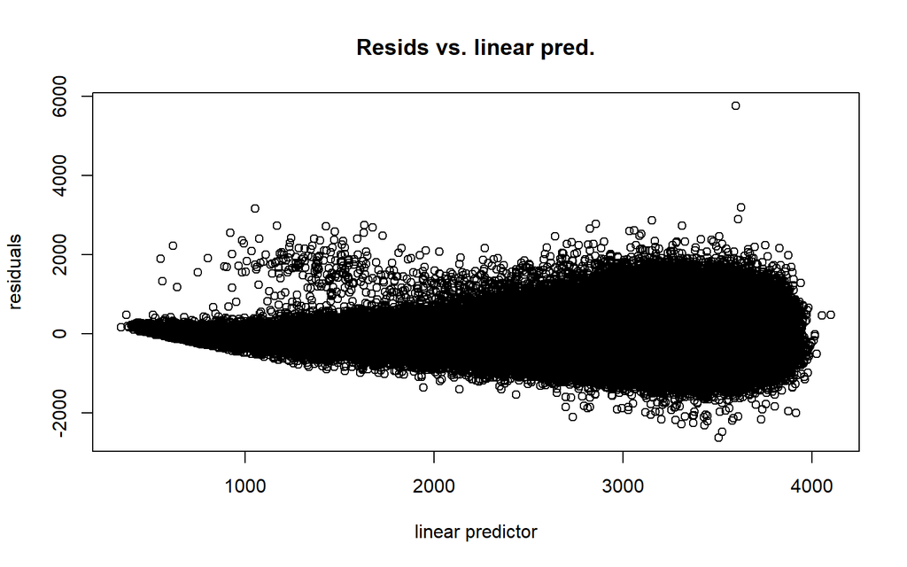

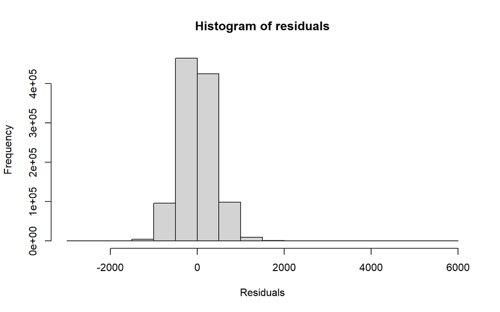

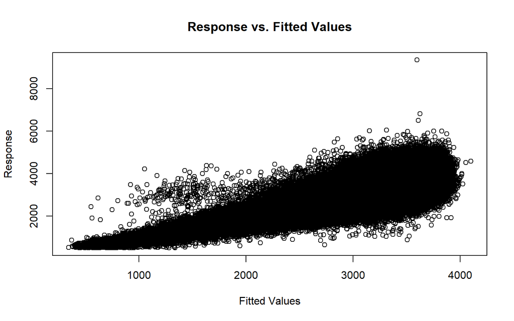

```
##
## Method: fREML   Optimizer: perf newton
## full convergence after 11 iterations.
## Gradient range [-0.07345475,0.05455442]
## (score 8120451 & scale 152594.7).
## Hessian positive definite, eigenvalue range [1.608974,549654.6].
## Model rank =  56 / 56
##
## Basis dimension (k) checking results. Low p-value (k-index<1) may
## indicate that k is too low, especially if edf is close to k'.
##
##                    k'  edf k-index p-value
## s(GA_weeks)      9.00 8.83    1.01    0.81
## s(mat_age)       6.00 5.18    1.02    0.85
## s(birth_Y_M_num) 9.00 8.28    1.02    0.95
## s(month)         9.00 5.89    1.02    0.92
## s(mean_ssep2)    9.00 7.63    1.03    0.98
```

```r
  gam.check(m_BW_bam5_2)
```

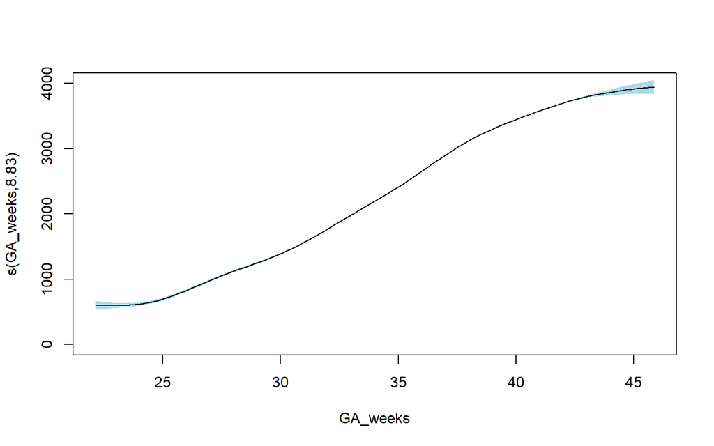

```r
  plot(m_BW_bam5_2, select=1, ylim=c(0, 4000),shade = TRUE, shade.col = "lightblue",  shift = coef(m_BW_bam5)[1])
```

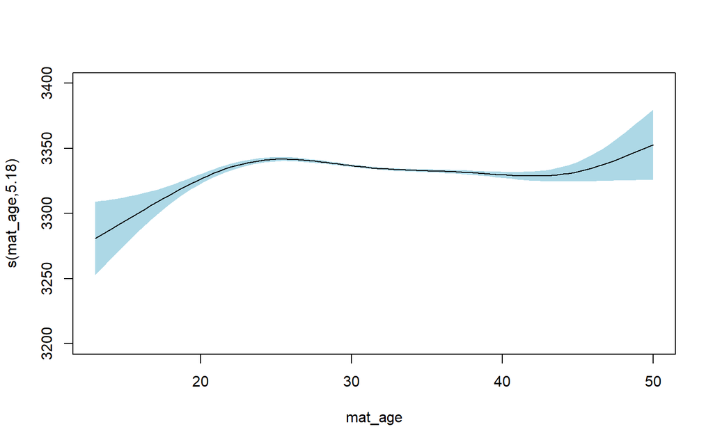

```r
  plot(m_BW_bam5_2, select=2, ylim=c(3200, 3400),shade = TRUE, shade.col = "lightblue",  shift = coef(m_BW_bam5_2)[1])
```

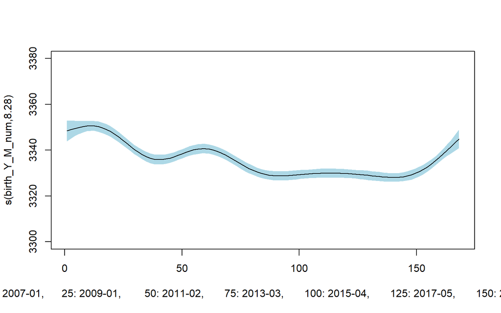

```r
  plot(m_BW_bam5_2, select=3, ylim=c(3300, 3380),shade = TRUE, shade.col = "lightblue",  shift = coef(m_BW_bam5_2)[1]  ,  xlab  = "0 : 2007-01,      25: 2009-01,        50: 2011-02,       75: 2013-03,       100: 2015-04,       125: 2017-05,       150: 2019-06"
)
```

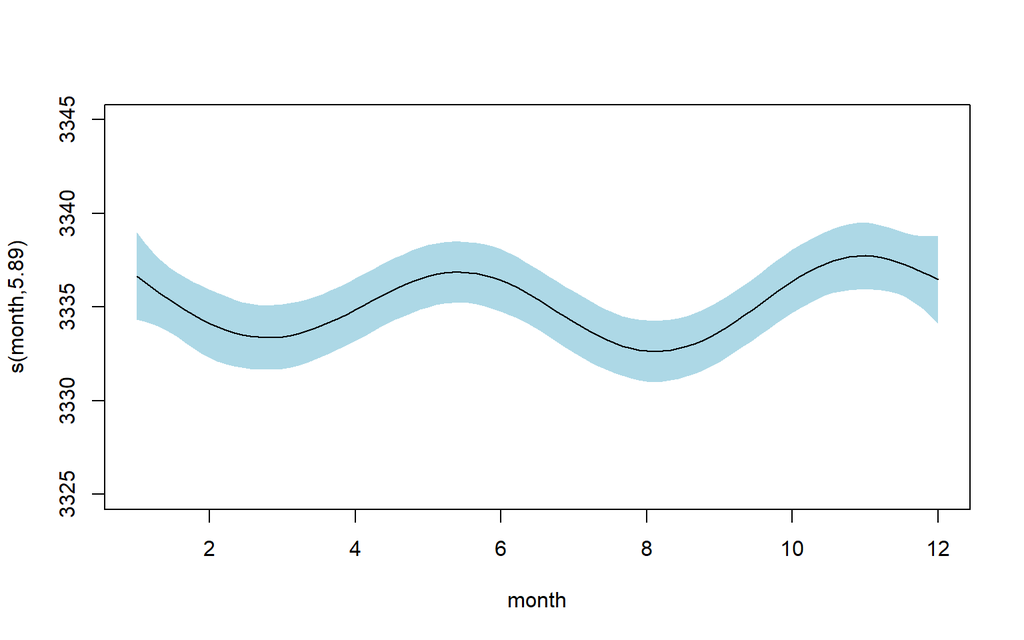

```r
  plot(m_BW_bam5_2, select=4, ylim=c(3325, 3345),shade = TRUE, shade.col = "lightblue",  shift = coef(m_BW_bam5_2)[1])
```

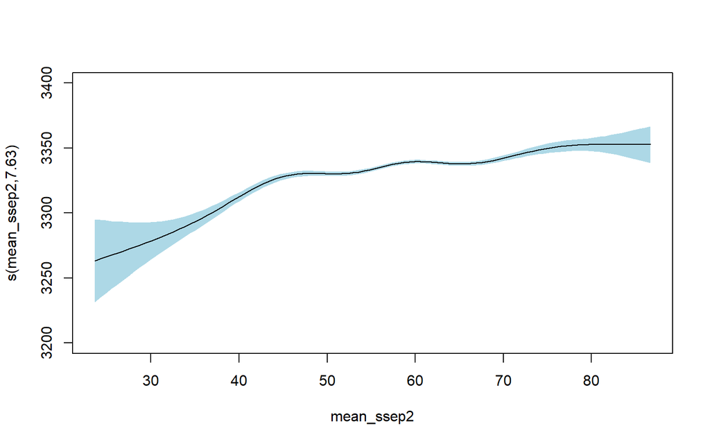

```r
  plot(m_BW_bam5_2, select=5, ylim=c(3200, 3400),shade = TRUE, shade.col = "lightblue",  shift = coef(m_BW_bam5_2)[1])
```

Cohen’s d formula:

$d=\frac{beta}{SD}$ and $SD=\sqrt{n}*se$

$d=\frac{beta}{\sqrt{n}*se}$

- beta: estimate
- se: standard error
- n: population/observation size
- SD: standard deviation

```r
#getting the CI 95% and d (interpret only for the non-smooth parameters)
  beta <- coef(m_BW_bam5_2)
  Vb <- vcov(m_BW_bam5_2, unconditional = TRUE)
  se <- sqrt(diag(Vb))
  n <- 1099328
  d <- (abs(beta)/(sqrt(n)*se))
  my.ci <- data.frame(cbind(beta, lci = beta-1.96*se, uci = beta + 1.96*se, d))
  round(head(my.ci,14), 2)
```

```
##                                                         beta     lci     uci    d
## (Intercept)                                          3335.27 3333.63 3336.91 3.80
## parity_cat(1,2]                                       127.47  125.83  129.10 0.15
## parity_cat(2,3]                                       173.63  171.12  176.13 0.13
## parity_cat(3,20]                                      199.70  195.36  204.04 0.09
## sex2                                                 -147.01 -148.47 -145.55 0.19
## Urban3                                                  0.66   -0.89    2.21 0.00
## LanguageFrench                                        -48.09  -49.89  -46.29 0.05
## LanguageItalian                                       -63.19  -67.20  -59.17 0.03
## mother_nationality_cat2Africa                          11.02    6.56   15.47 0.00
## mother_nationality_cat2Asia                           -17.93  -21.96  -13.89 0.01
## mother_nationality_cat2Europe                          32.57   30.90   34.23 0.04
## mother_nationality_cat2Northern America                65.01   55.49   74.52 0.01
## mother_nationality_cat2Oceania                         63.47   41.66   85.28 0.01
## mother_nationality_cat2Southern and Central America    47.05   41.56   52.54 0.02
```

Interpretation of m_BW_bam5_2 model :

- Non-smooth terms

Increasing parity increases birthweight compared to first births: from (126g, 129g) at second parity, (171g, 176g) at third parity, to (195g, 204g) for parities over 3.

Being born female decreases by (-148g, -146g) compared to males.

Urbanicity has no effect on birthweight.

Language: Compared to babies born in German(+Romansh)-speaking Switzerland, being born in the French-speaking part decreases BW by (-50g,-46g), while being born in the Italian-speaking part decreases BW by (-67g,-59g).

Maternal nationality: compared to babies born from Swiss mothers, babies born from Asian mothers are lighter (-22g, -14g). Babies born from other-nationalities mothers are heavier: (7g, 16g) for Africa, (31g, 34g) for other European countries, (55g, 75g) for Northern America, (42g, 86g) for Oceania, and (42g-53g) for Southern/Central America.

- Smooth terms

Time (month+year combined): globally, birthweight is decreasing between 2007 and 2019 from 3350 to 3330 which is a minor change, and then increases from 2019 to reach 3350g. There are some other minor variations throughtout the whole time but this doesnt seem very relevant: only 20g variation.

Seasonal/month: minor sinusoidal seasonal variation between 3330-3340g, with lower birthweight in March and August. These difference dont seem much relevant either (10g variation will probably not impact the baby’s health).

Mean ssep: Birthweight increases by increasing ssep, linearly between ssep=25-45 approx (3250-3340g), and then there is some minor birthweight increase for higher ssep, until reaching a BW of around 3360g. Overall, a +100g increase is probably worht mentioning.

## 2008-2010

Because birth_Y_M_num and month variables correlated too much, moth variable was not kept in the model

```r
  m_BW_bam_2009_2 <- bam(BW ~ s(GA_weeks) +  s(mat_age, k=7) + s(birth_Y_M_num) + s(mean_ssep2) + parity_cat + sex + Urban3  + Language + mother_nationality_cat2, data=bevn_eco_in7_2008_10)
  summary(m_BW_bam_2009_2)
```

```
##
## Family: gaussian
## Link function: identity
##
## Formula:
## BW ~ s(GA_weeks) + s(mat_age, k = 7) + s(birth_Y_M_num) + s(mean_ssep2) +
##     parity_cat + sex + Urban3 + Language + mother_nationality_cat2
##
## Parametric coefficients:
##                                                       Estimate Std. Error  t value Pr(>|t|)
## (Intercept)                                          3329.5609     1.8663 1784.075  < 2e-16 ***
## parity_cat(1,2]                                       122.1534     1.8847   64.813  < 2e-16 ***
## parity_cat(2,3]                                       172.2947     2.8838   59.746  < 2e-16 ***
## parity_cat(3,20]                                      196.5619     4.9231   39.926  < 2e-16 ***
## sex2                                                 -146.2210     1.6800  -87.037  < 2e-16 ***
## Urban3                                                  0.8197     1.7448    0.470  0.63851
## LanguageFrench                                        -45.9766     2.0609  -22.309  < 2e-16 ***
## LanguageItalian                                       -65.0958     4.3465  -14.977  < 2e-16 ***
## mother_nationality_cat2Africa                          41.2721     6.0377    6.836 8.18e-12 ***
## mother_nationality_cat2Asia                           -15.2504     4.9412   -3.086  0.00203 **
## mother_nationality_cat2Europe                          36.4670     1.9396   18.801  < 2e-16 ***
## mother_nationality_cat2Northern America                82.8571    10.6237    7.799 6.25e-15 ***
## mother_nationality_cat2Oceania                         54.3021    24.9696    2.175  0.02965 *
## mother_nationality_cat2Southern and Central America    60.6874     6.0057   10.105  < 2e-16 ***
## ---
## Signif. codes:  0 '***' 0.001 '**' 0.01 '*' 0.05 '.' 0.1 ' ' 1
##
## Approximate significance of smooth terms:
##                    edf Ref.df         F  p-value
## s(GA_weeks)      8.246  8.808 14713.983  < 2e-16 ***
## s(mat_age)       3.134  3.771     7.669 1.06e-05 ***
## s(birth_Y_M_num) 2.838  3.533    14.969  < 2e-16 ***
## s(mean_ssep2)    1.005  1.010    70.173  < 2e-16 ***
## ---
## Signif. codes:  0 '***' 0.001 '**' 0.01 '*' 0.05 '.' 0.1 ' ' 1
##
## R-sq.(adj) =  0.397   Deviance explained = 39.7%
## fREML = 1.6251e+06  Scale est. = 1.548e+05  n = 219790
```

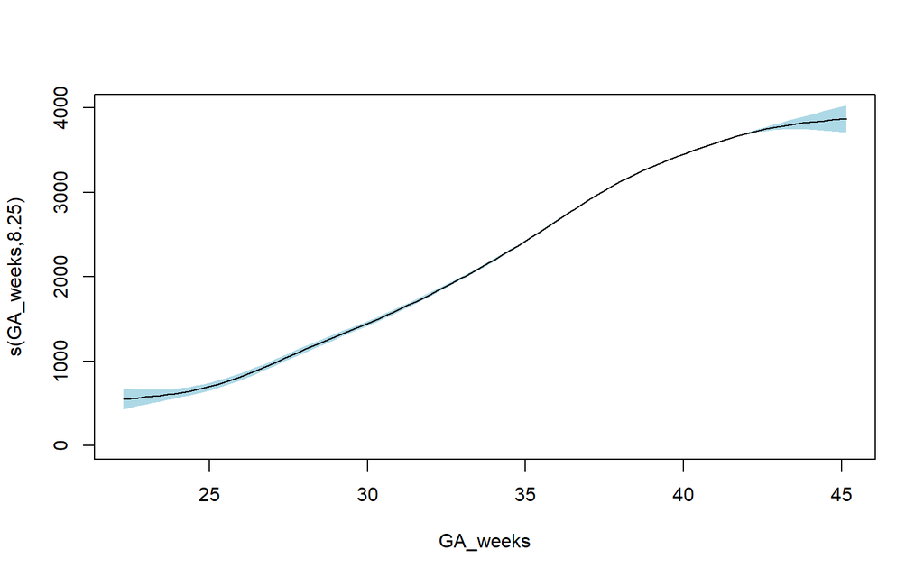

```r
  plot(m_BW_bam_2009_2, select=1, ylim=c(0, 4000),shade = TRUE, shade.col = "lightblue",shift = coef(m_BW_bam_2009_2)[1])
```

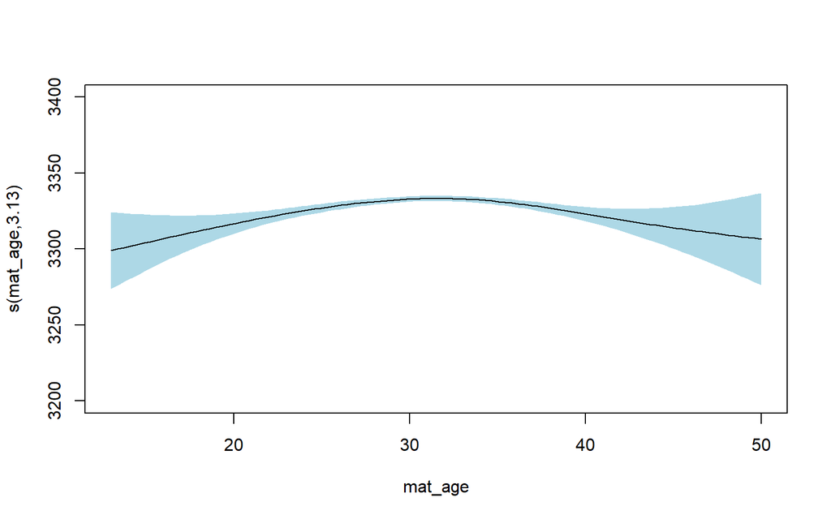

```r
  plot(m_BW_bam_2009_2, select=2, ylim=c(3200, 3400),shade = TRUE, shade.col = "lightblue",shift = coef(m_BW_bam_2009_2)[1])
```

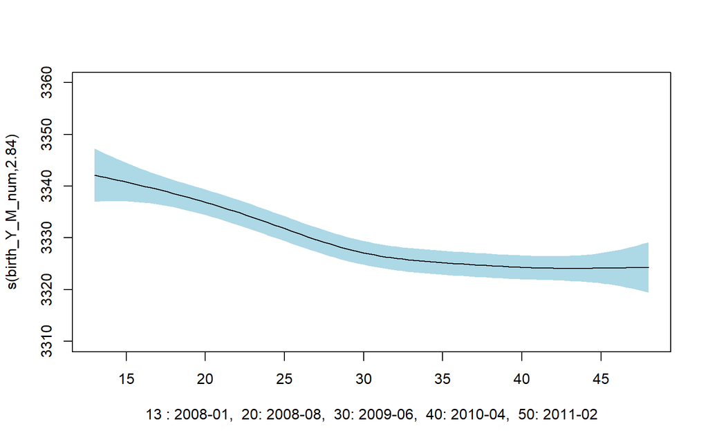

```r
  plot(m_BW_bam_2009_2, select=3, ylim=c(3310, 3360),shade = TRUE, shade.col = "lightblue", shift = coef(m_BW_bam_2009_2)[1],  xlab  = "13 : 2008-01,  20: 2008-08,  30: 2009-06,  40: 2010-04,  50: 2011-02")
```

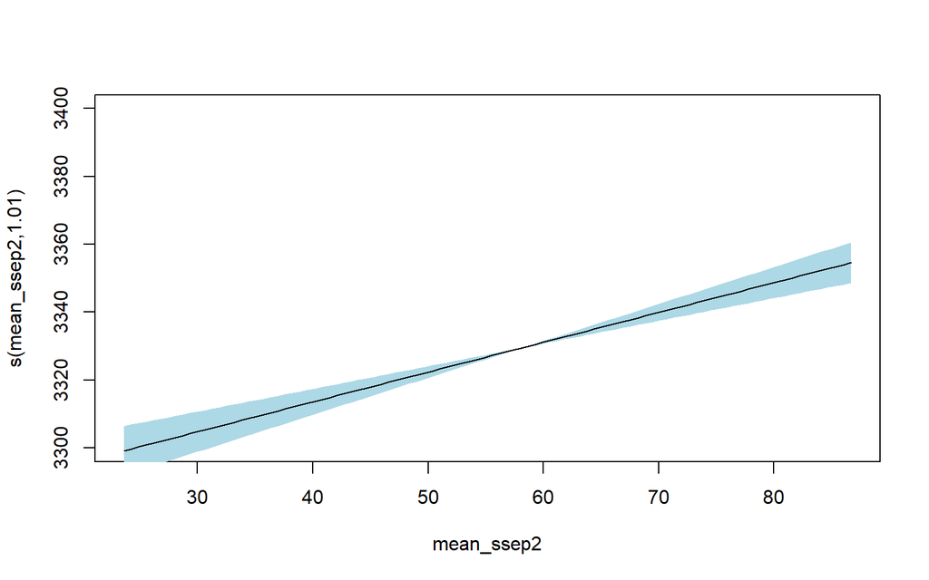

```r
    plot(m_BW_bam_2009_2, select=4, ylim=c(3300, 3400),shade = TRUE, shade.col = "lightblue", shift = coef(m_BW_bam_2009_2)[1])
```

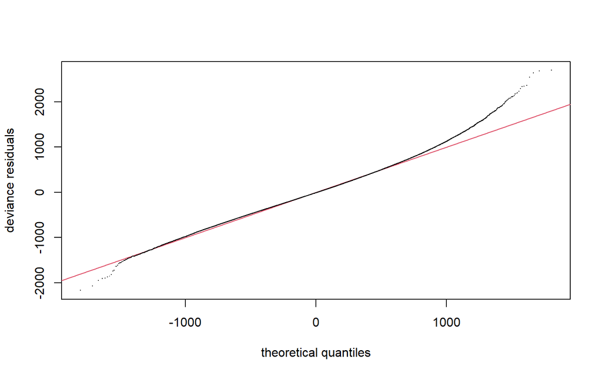

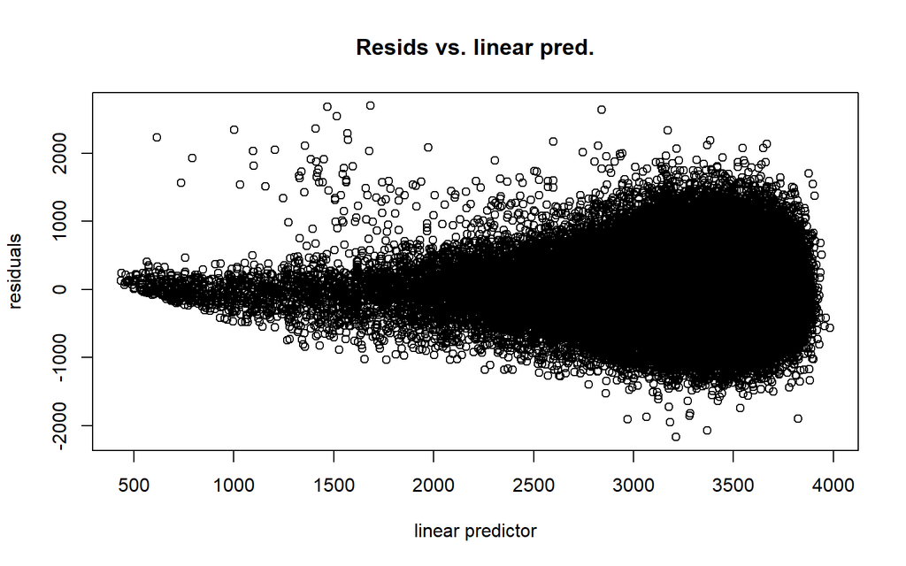

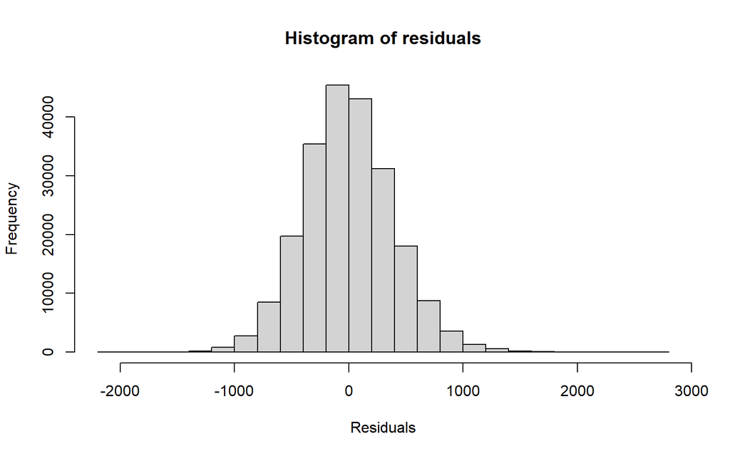

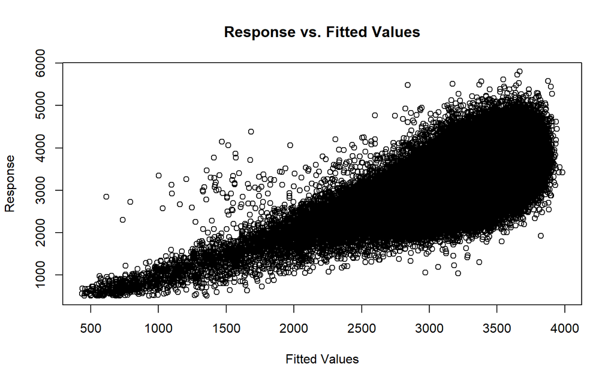

```
##
## Method: fREML   Optimizer: perf newton
## full convergence after 9 iterations.
## Gradient range [-0.00627723,0.003296825]
## (score 1625081 & scale 154802.2).
## Hessian positive definite, eigenvalue range [0.001899672,109886].
## Model rank =  47 / 47
##
## Basis dimension (k) checking results. Low p-value (k-index<1) may
## indicate that k is too low, especially if edf is close to k'.
##
##                    k'  edf k-index p-value
## s(GA_weeks)      9.00 8.25    1.00    0.57
## s(mat_age)       6.00 3.13    1.03    0.97
## s(birth_Y_M_num) 9.00 2.84    0.98    0.12
## s(mean_ssep2)    9.00 1.01    0.99    0.28
```

```r
  gam.check(m_BW_bam_2009_2)
```

```r
  concurvity(m_BW_bam_2009_2, full=TRUE) #values are now fine.
```

```
##               para s(GA_weeks) s(mat_age) s(birth_Y_M_num) s(mean_ssep2)
## worst    0.7984747 0.016036158 0.13810148      0.005944672    0.18023607
## observed 0.7984747 0.006453183 0.02803196      0.005514778    0.13958911
## estimate 0.7984747 0.009270530 0.08640908      0.003387016    0.08255867
```

```r
  # Summary of estimates, CI95% and Cohen's d
  beta <- coef(m_BW_bam_2009_2)
  Vb <- vcov(m_BW_bam_2009_2, unconditional = TRUE)
  se <- sqrt(diag(Vb2))
  n <- 219790
  d <- (abs(beta)/(sqrt(n)*se))
  my.ci2 <- data.frame(cbind(beta2, lci = beta2-1.96*se2, uci = beta2 + 1.96*se2, d))
  round(head(my.ci2,14), 2)
```

[output not shown]

## 2017-2020

We also did not use the month variable because of correlation between month and time (birth_Y_M_num) variables.

```r
  m_BW_bam_covid_2 <- bam(BW ~ s(GA_weeks) +  s(mat_age) + s(birth_Y_M_num) + s(mean_ssep2) + parity_cat + sex + Urban3  + Language + mother_nationality_cat2, data=bevn_eco_in7_2017_20)
  summary(m_BW_bam_covid)
```

[output not shown]

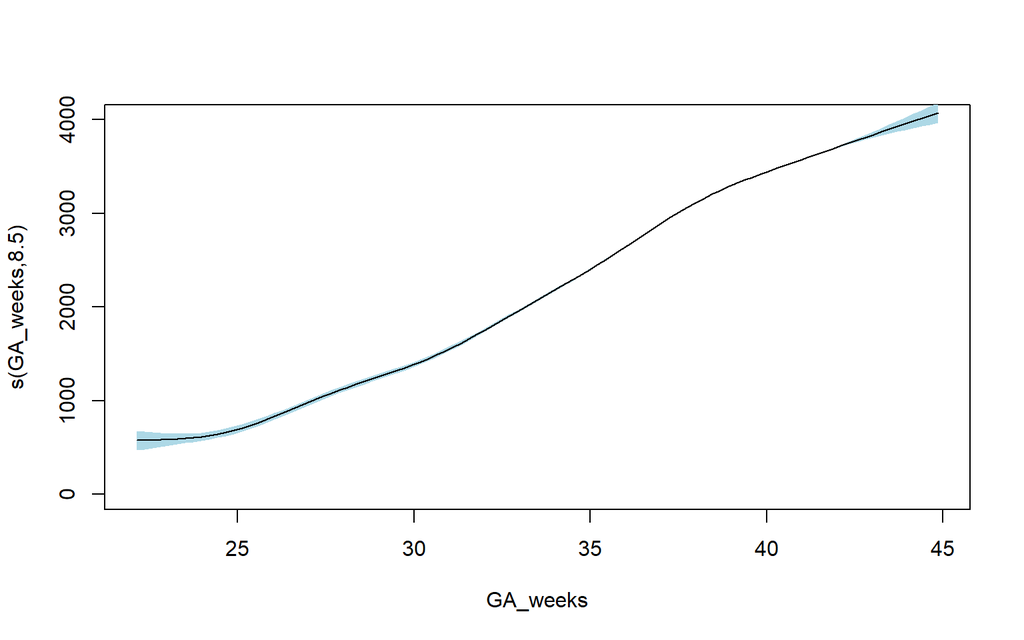

```r
  plot(m_BW_bam_covid_2, select=1, ylim=c(0, 4000),shade = TRUE, shade.col = "lightblue",shift = coef(m_BW_bam_covid_2)[1])
```

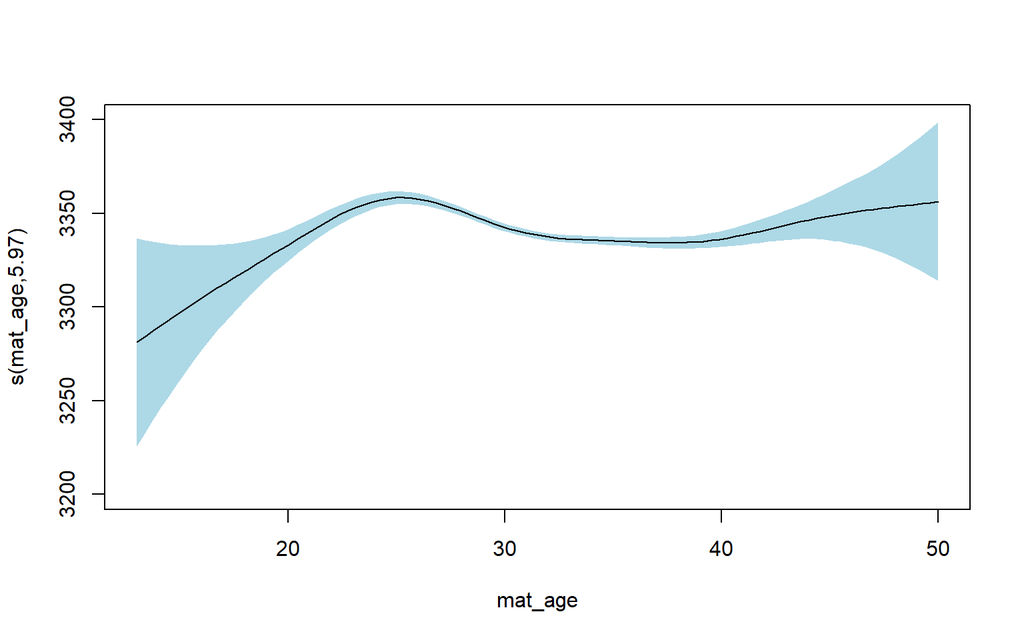

```r
  plot(m_BW_bam_covid_2, select=2, ylim=c(3200, 3400),shade = TRUE, shade.col = "lightblue",shift = coef(m_BW_bam_covid_2)[1])
```

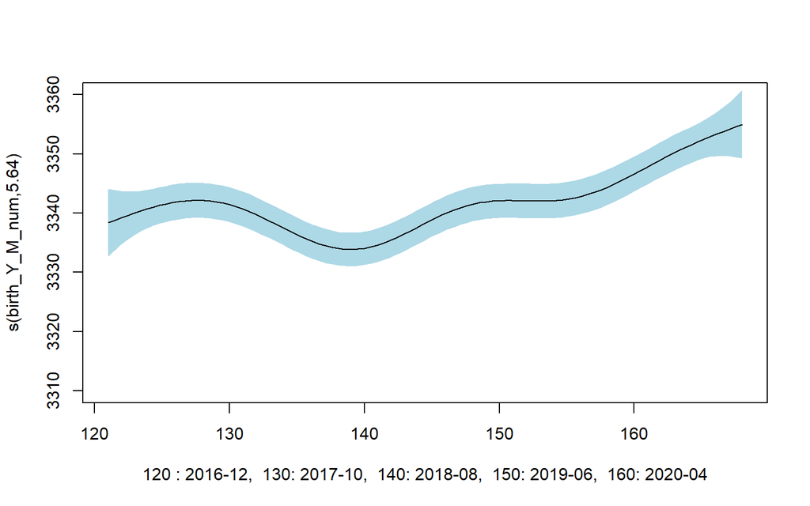

```r
  plot(m_BW_bam_covid_2, select=3, ylim=c(3310, 3360),shade = TRUE, shade.col = "lightblue", shift = coef(m_BW_bam_covid_2)[1],xlab  = "120 : 2016-12,  130: 2017-10,  140: 2018-08,  150: 2019-06,  160: 2020-04")
```

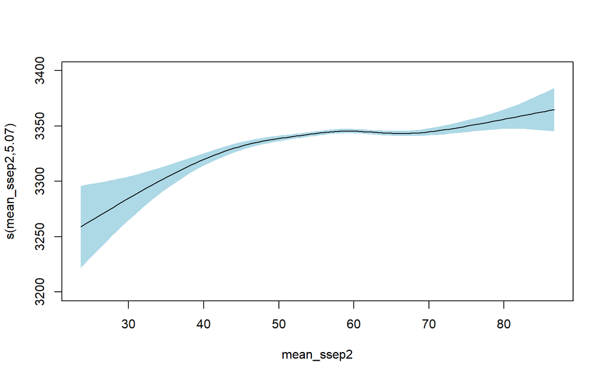

```r
  plot(m_BW_bam_covid_2, select=4, ylim=c(3200, 3400),shade = TRUE, shade.col = "lightblue", shift = coef(m_BW_bam_covid_2)[1])
```

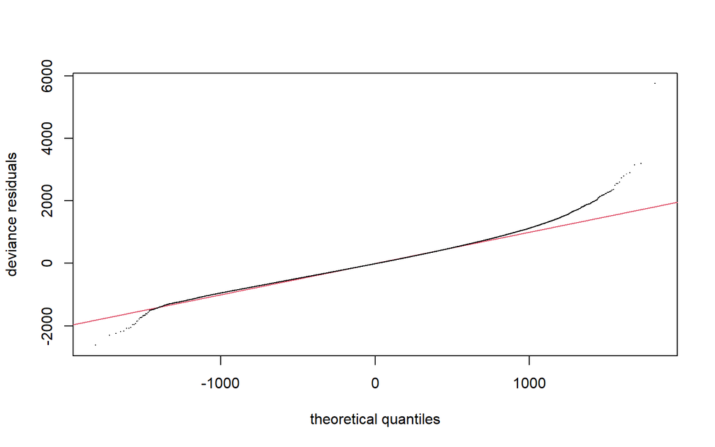

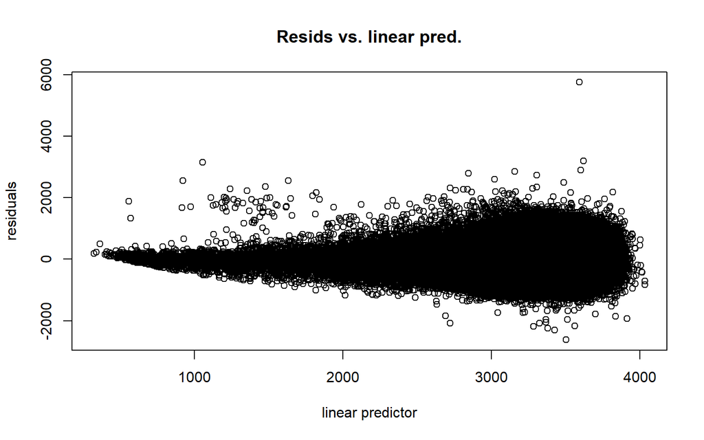

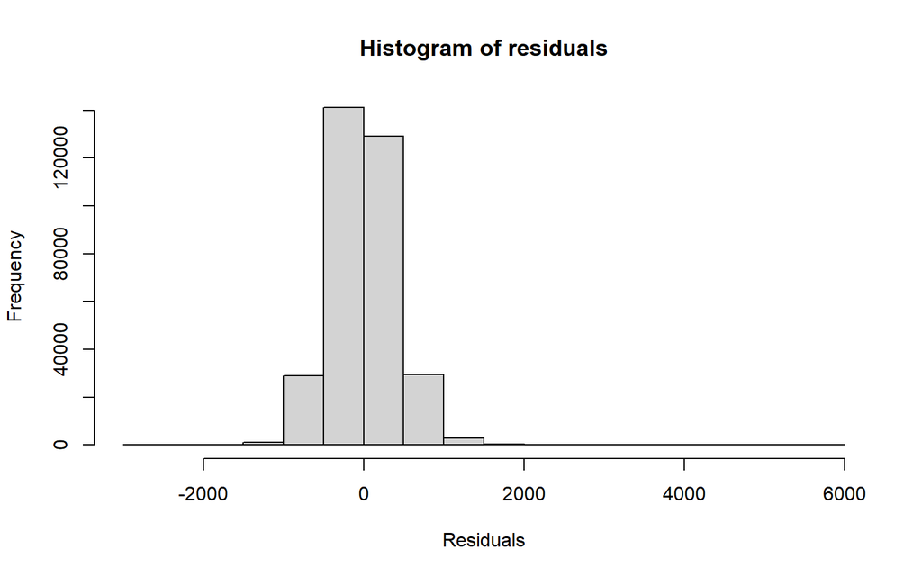

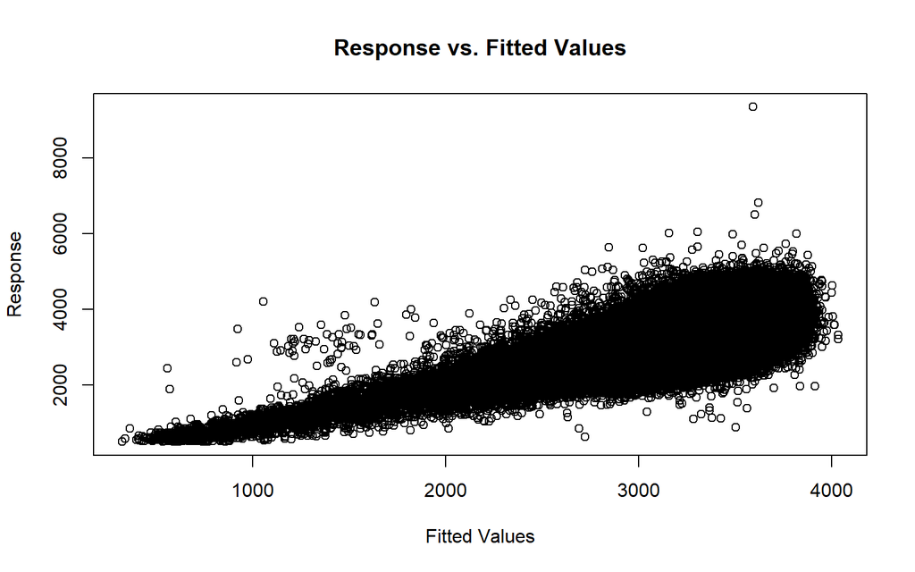

```
##
## Method: fREML   Optimizer: perf newton
## full convergence after 12 iterations.
## Gradient range [-0.02525633,0.01270513]
## (score 2455714 & scale 150566.6).
## Hessian positive definite, eigenvalue range [0.9639783,166367].
## Model rank =  50 / 50
##
## Basis dimension (k) checking results. Low p-value (k-index<1) may
## indicate that k is too low, especially if edf is close to k'.
##
##                    k'  edf k-index p-value
## s(GA_weeks)      9.00 8.50    0.99    0.21
## s(mat_age)       9.00 5.97    1.01    0.84
## s(birth_Y_M_num) 9.00 5.64    1.00    0.46
## s(mean_ssep2)    9.00 5.07    0.99    0.39
```

```r
  gam.check(m_BW_bam_covid_2)
```

```r
  concurvity(m_BW_bam_covid_2, full=TRUE) #values are now fine.
```

```
##               para s(GA_weeks) s(mat_age) s(birth_Y_M_num) s(mean_ssep2)
## worst    0.8025004 0.018718378 0.10868673     0.0012305866    0.17778115
## observed 0.8025004 0.007202263 0.06041256     0.0006853439    0.08805890
## estimate 0.8025004 0.010886632 0.06965186     0.0009594351    0.08022341
```

```r
  # Summary of estimates, CI95% and Cohen's d
  beta3 <- coef(m_BW_bam_covid_2)
  Vb3 <- vcov(m_BW_bam_covid_2, unconditional = TRUE)
  se3 <- sqrt(diag(Vb3))
  n <- 332752
  my.ci3 <- data.frame(cbind(beta3, lci = beta3-1.96*se3, uci = beta3 + 1.96*se3, d))
  round(head(my.ci3,14), 2)
```

```
##                                                        beta3     lci     uci    d
## (Intercept)                                          3341.81 3338.84 3344.77 3.81
## parity_cat(1,2]                                       132.57  129.62  135.52 0.14
## parity_cat(2,3]                                       180.82  176.33  185.32 0.13
## parity_cat(3,20]                                      202.27  194.42  210.11 0.09
## sex2                                                 -144.72 -147.36 -142.08 0.19
## Urban3                                                 -0.10   -2.90    2.69 0.00
## LanguageFrench                                        -51.18  -54.38  -47.97 0.05
## LanguageItalian                                       -62.49  -70.23  -54.74 0.03
## mother_nationality_cat2Africa                          -6.51  -13.90    0.87 0.01
## mother_nationality_cat2Asia                           -16.40  -23.35   -9.45 0.01
## mother_nationality_cat2Europe                          27.21   24.23   30.20 0.04
## mother_nationality_cat2Northern America                59.93   42.24   77.63 0.02
## mother_nationality_cat2Oceania                         60.92   17.24  104.61 0.00
## mother_nationality_cat2Southern and Central America    38.20   27.68   48.72 0.02
```

# Stillbirth

## 2007-2020

```r
m_SB_bam2 <- bam(stillbirth~s(GA_weeks)+ s(mat_age, k=7) + s(month) + birth_Y_M_num + mean_ssep2 + Urban3 + Language + mother_nationality_cat2,family="binomial", data=bevn_eco_in6)
  summary(m_SB_bam2)
```

```
##
## Family: binomial
## Link function: logit
##
## Formula:
## stillbirth ~ s(GA_weeks) + s(mat_age, k = 7) + s(month) + birth_Y_M_num +
##     mean_ssep2 + Urban3 + Language + mother_nationality_cat2
##
## Parametric coefficients:
##                                                        Estimate Std. Error z value Pr(>|z|)
## (Intercept)                                          -6.619e+00  1.456e-01 -45.452  < 2e-16 ***
## birth_Y_M_num                                         4.545e-05  3.972e-04   0.114  0.90891
## mean_ssep2                                           -6.094e-03  2.332e-03  -2.614  0.00896 **
## Urban3                                                3.814e-02  3.892e-02   0.980  0.32712
## LanguageFrench                                        8.110e-02  4.404e-02   1.842  0.06554 .
## LanguageItalian                                      -2.043e-02  1.024e-01  -0.200  0.84185
## mother_nationality_cat2Africa                         2.275e-01  9.350e-02   2.434  0.01495 *
## mother_nationality_cat2Asia                          -3.683e-02  1.016e-01  -0.362  0.71708
## mother_nationality_cat2Europe                         3.175e-02  4.253e-02   0.747  0.45532
## mother_nationality_cat2Northern America              -3.488e-01  2.851e-01  -1.223  0.22121
## mother_nationality_cat2Oceania                       -1.733e-01  7.207e-01  -0.241  0.80993
## mother_nationality_cat2Southern and Central America  -9.889e-02  1.351e-01  -0.732  0.46426
## ---
## Signif. codes:  0 '***' 0.001 '**' 0.01 '*' 0.05 '.' 0.1 ' ' 1
##
## Approximate significance of smooth terms:
##               edf Ref.df    Chi.sq p-value
## s(GA_weeks) 7.589  8.143 16734.305  <2e-16 ***
## s(mat_age)  3.147  3.820    13.061  0.0105 *
## s(month)    2.627  3.267     7.216  0.0701 .
## ---
## Signif. codes:  0 '***' 0.001 '**' 0.01 '*' 0.05 '.' 0.1 ' ' 1
##
## R-sq.(adj) =  0.133   Deviance explained = 32.1%
## fREML = 1.5655e+06  Scale est. = 1         n = 1102617
```

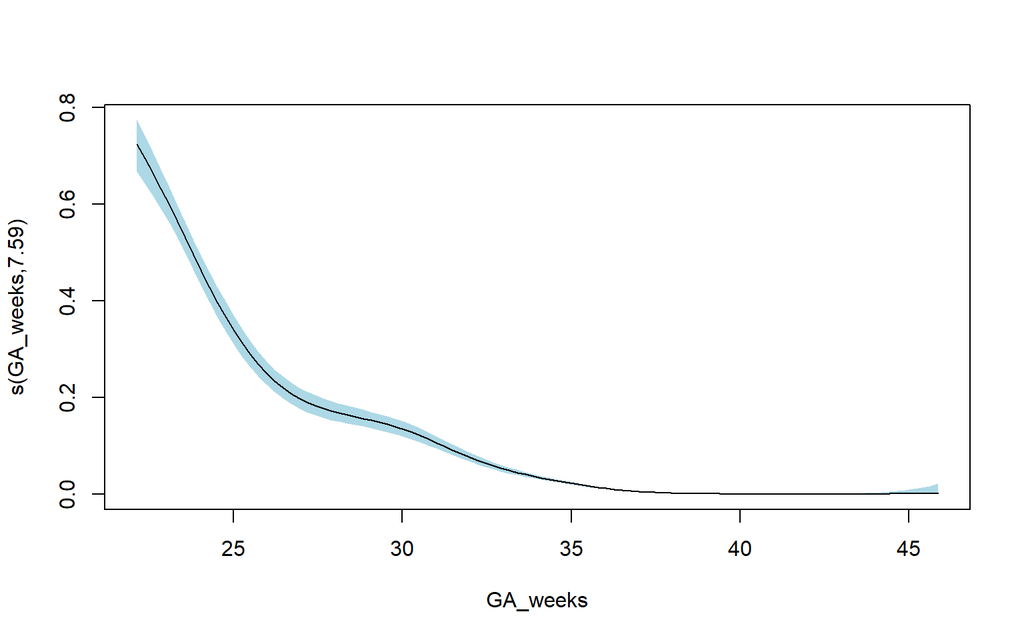

```r
  plot(m_SB_bam2, trans = plogis, select=1, shift = coef(m_SB_bam2)[1], shade = TRUE, shade.col = "lightblue") #GA
```

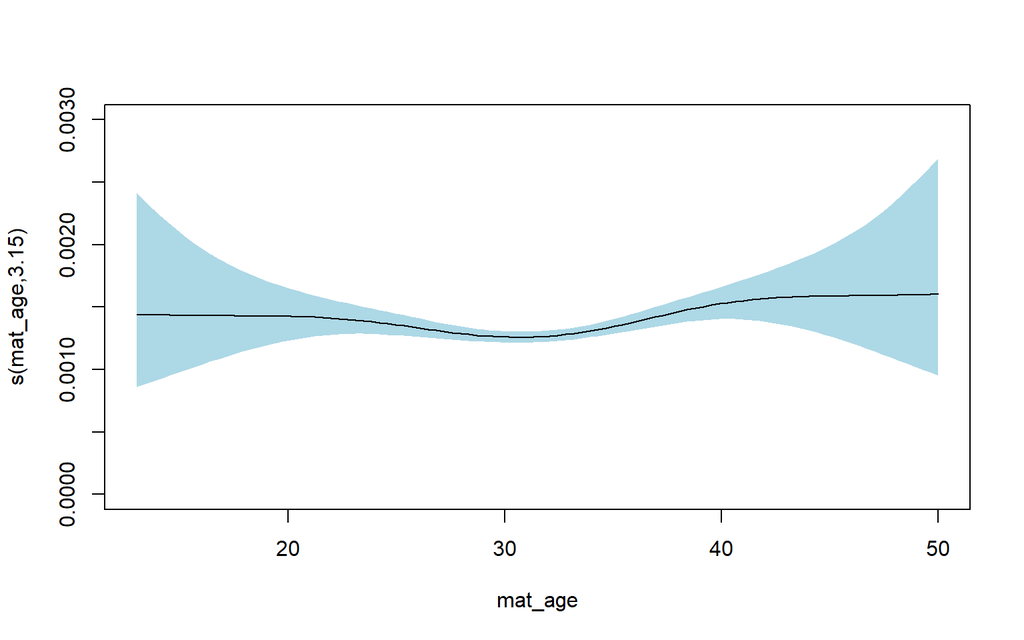

```r
  plot(m_SB_bam2, trans = plogis, select=2, ylim=c(0, 0.003), shift = coef(m_SB_bam2)[1], shade = TRUE, shade.col = "lightblue") #mat age
```

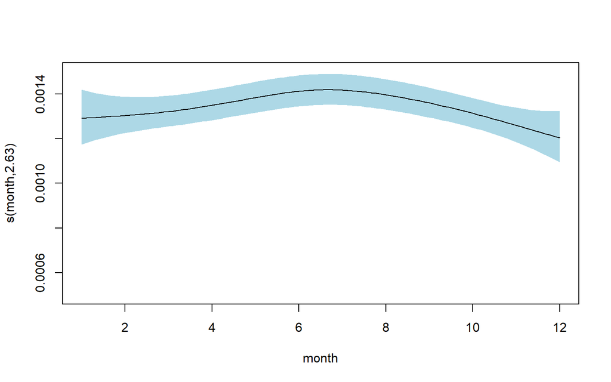

```r
  plot(m_SB_bam2, trans = plogis, select=3, ylim=c(0.0005, 0.0015), shift = coef(m_SB_bam2)[1], shade = TRUE, shade.col = "lightblue") #month
```

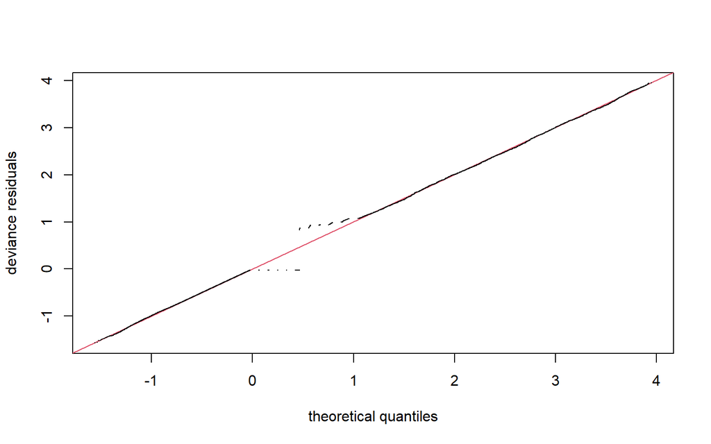

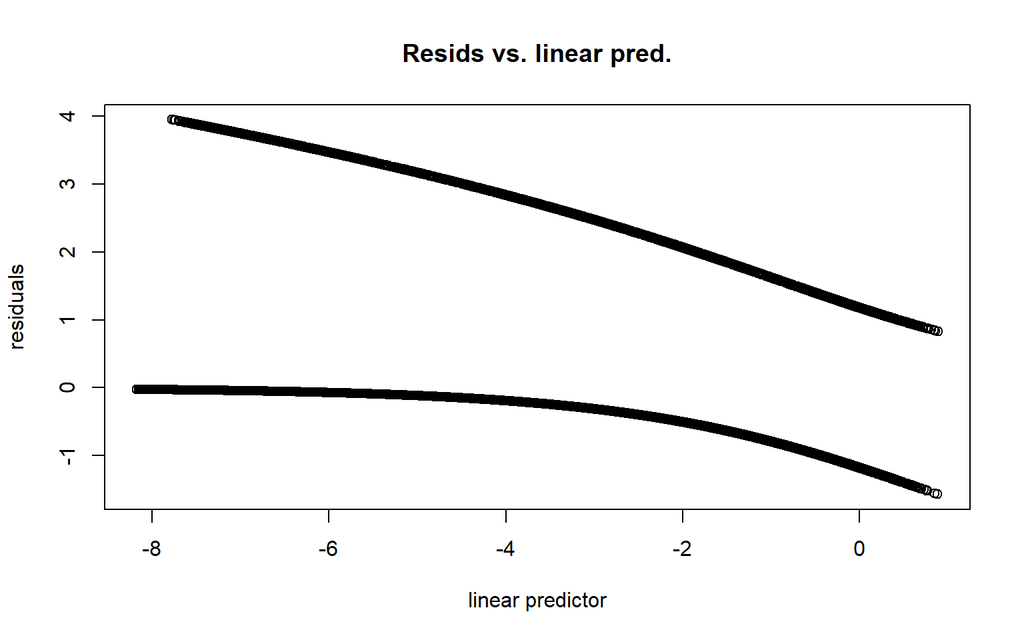

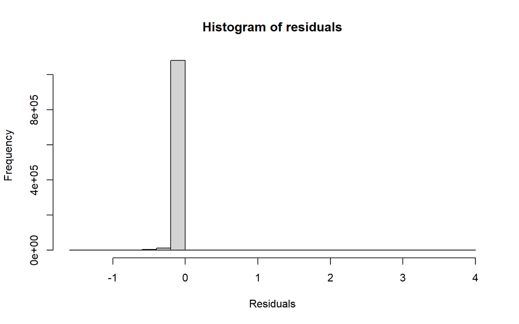

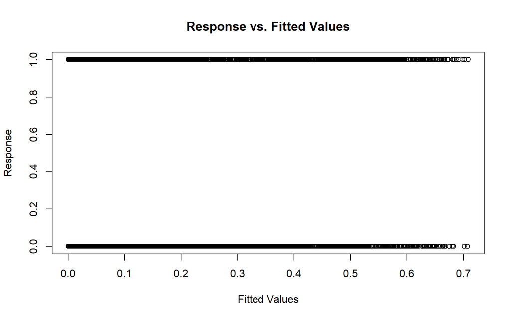

```
##
## Method: fREML   Optimizer: perf newton
## full convergence after 5 iterations.
## Gradient range [-1.942944e-08,4.678661e-05]
## (score 1565532 & scale 1).
## Hessian positive definite, eigenvalue range [0.4428412,2.850118].
## Model rank =  36 / 36
##
## Basis dimension (k) checking results. Low p-value (k-index<1) may
## indicate that k is too low, especially if edf is close to k'.
##
##               k'  edf k-index p-value
## s(GA_weeks) 9.00 7.59    0.87   0.015 *
## s(mat_age)  6.00 3.15    0.94   0.775
## s(month)    9.00 2.63    0.94   0.335
## ---
## Signif. codes:  0 '***' 0.001 '**' 0.01 '*' 0.05 '.' 0.1 ' ' 1
```

```r
  gam.check(m_SB_bam2)
```

```r
  concurvity(m_SB_bam2)
```

```
##               para s(GA_weeks) s(mat_age)     s(month)
## worst    0.9829412 0.010976422 0.05328595 0.0045643900
## observed 0.9829412 0.005611189 0.01081304 0.0005238286
## estimate 0.9829412 0.007092571 0.03420192 0.0034099344
```

Calculation of Cohen’s d for OR:

$d= \log(OR) * \frac{\sqrt{3}}{\pi}$